# My VK

Skvortsov Grigory

June, 2017

```r
library(igraph)
library(vkR)
```

## 1 Your Network Summary

First of all, we need to read .json the file and build the graph. ### Network source and preprocessing Read our graph from .csv file (How it got described in paragraph 4). Remove the loop and NA elements.

```r
g_t <- read.csv("/home/skv/sna_skvortsov/edgelist.csv", header=FALSE, sep=",")
graph <- graph.data.frame(g_t, directed=FALSE)

graph <- delete_edges(graph,incident(graph, "NA"))
graph <- delete_vertices(graph, "NA")
graph <- simplify(graph, remove.multiple = TRUE, remove.loops = FALSE)
```

### Node/Edge attributes

Every edge in the graph has the same weight, that equals to 1. The labels of vertexes are ids of users from VK.

### Size, Order

I have 79 friends in vk.com

```r
vcount(graph)
```

```
## [1] 79
```

Size

```r
ecount(graph)
```

```
## [1] 339
```

### Gorgeous network layout.

I built my graph using Gephi (with installed plugin LabelPropagation). The vertex color mainly depends on the community (fot that i used LabelPropogation applet). Size tops helps to estimate the number of edges incoming to this vertex

[figure not shown]

### Degree distribution, Shortest Path distribution, Diameter, Radius, Clustering Coefficients (local distribution and global)

Let’s build PDF and CDF of the degree distribution in log-log scale, as we did it in 4th assignment.

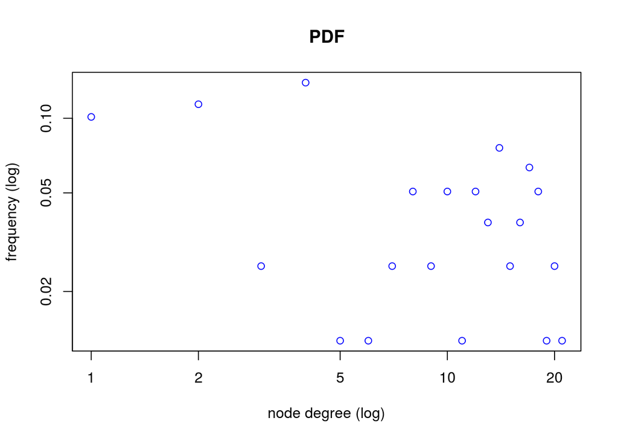

```r
## get PDF and CDF
max_degree <- max(degree(graph))
degree_range <- 1:max_degree
degree_dist <- degree.distribution(graph, cumulative = FALSE)[degree_range]

## delete zero values
positive_position <- which(degree_dist  > 0)
degree_dist <- degree_dist[positive_position]
degree_range <- degree_range[positive_position]
cum_degree_range <- degree_range + 1
compl_cum_degree_range <- cum_degree_range

cum_degree_dist <- cumsum(degree_dist)
compl_cum_degree_dist <- degree.distribution(graph, cumulative=TRUE)[cum_degree_range]
compl_cum_degree_dist <- compl_cum_degree_dist[cum_degree_range]

plot(degree_dist, log = "xy", main = "PDF", xlab = "node degree (log)", ylab = "frequency (log)", col="blue")
```

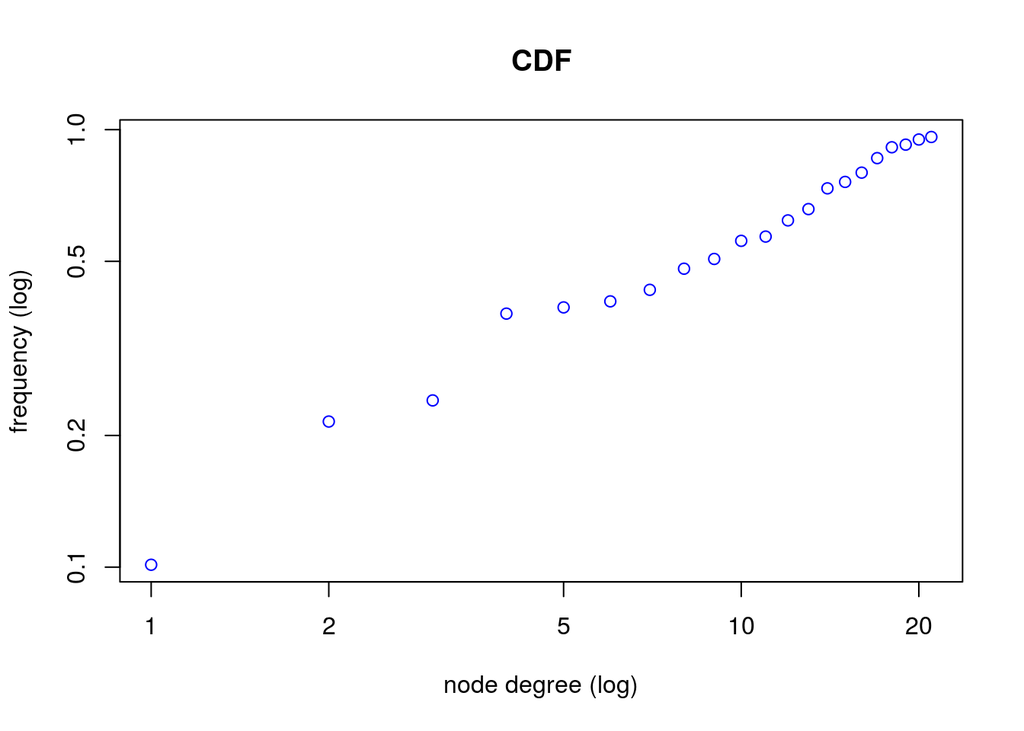

```r
plot(cum_degree_dist, log = "xy", main = "CDF", xlab = "node degree (log)", ylab = "frequency (log)", col="blue")
```

Shortest Path distribution

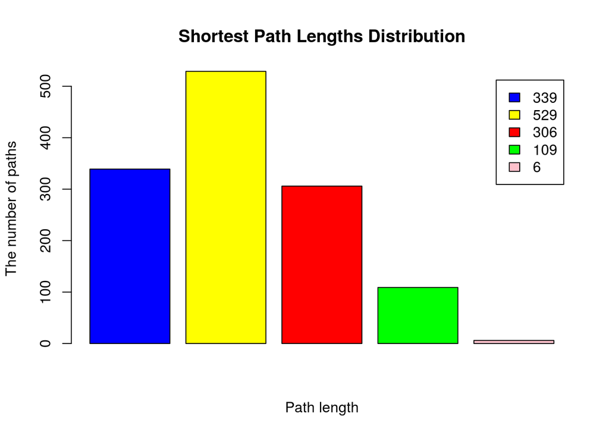

```r
barplot(path.length.hist(graph)$res, legend = path.length.hist(graph)$res, main = "Shortest Path Lengths Distribution", col = c("blue", "yellow", "red","green", "pink"),xlab = "Path length", ylab = "The number of paths" )
```

Dismeter and radius. Diametr is the length of the “longest shortest path”, radius is the length of the shortest paths among longest ones.

```r
diameter(graph)
```

```
## [1] 5
```

```r
radius(graph)
```

```
## [1] 0
```

Clustering Coefficients (local distribution and global)

```r
#LOCAL
local_cluster <- transitivity(graph, type="local")
print("local_cluster_coeff")
```

```
## [1] "local_cluster_coeff"
```

```r
local_cluster
```

```
##  [1] 0.9333333       NaN       NaN       NaN       NaN       NaN       NaN
##  [8]       NaN       NaN 0.6000000 0.0000000       NaN 0.5256410 0.3246753
## [15] 0.5000000       NaN 0.5588235 0.7142857 0.6666667 0.6666667       NaN
## [22] 1.0000000 0.4242424 0.4632353       NaN       NaN 0.4476190 0.4909091
## [29] 0.5000000 0.4705882 0.6969697 1.0000000 1.0000000 0.3982684 0.6060606
## [36]       NaN 0.5777778       NaN 0.3333333 0.7692308 0.5735294 0.7583333
## [43] 1.0000000 0.7222222 0.6025641 0.8363636 0.4166667 0.6000000 1.0000000
## [50] 0.4583333 0.6944444 0.9285714 0.7416667       NaN 0.7238095 0.7619048
## [57] 0.6105263 0.5454545 0.8974359 0.9090909 0.8717949 0.6666667 0.8241758
## [64] 0.2380952 1.0000000 0.6923077 0.3333333 0.5751634 0.9444444 0.6428571
## [71] 0.9523810 0.6023392       NaN 0.8727273 1.0000000 1.0000000 0.6725146
## [78] 0.7564103 0.8611111
```

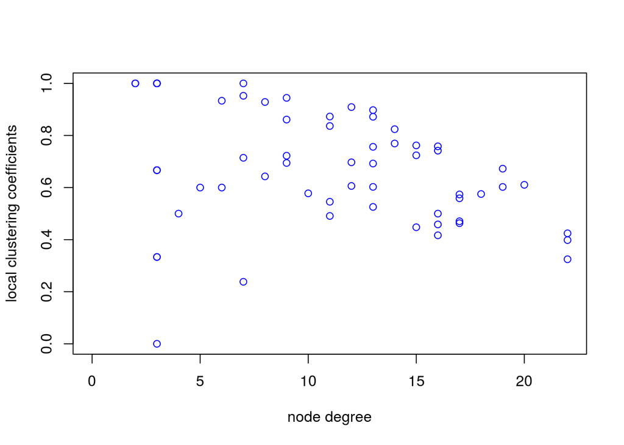

```r
plot(degree(graph), local_cluster, xlab="node degree", ylab="local clustering coefficients", col="blue")
```

```r
#GLOBAL
global_cluster <- transitivity(graph, type="global")
print("global_cluster_coeff")
```

```
## [1] "global_cluster_coeff"
```

```r
global_cluster
```

```
## [1] 0.602781
```

## 2 Structural Analysis

### Degree/Closeness/Betweenness centralities. Top nodes interpretation

Find these centrality metric

```r
deg_c <- degree(graph)
clos_c <- closeness(graph)
betw_c <- betweenness(graph)
```

Lets interpet results. So I chose top-5 nodes for each metric.

```r
deg_c_ids <- sort(deg_c, decreasing=TRUE)[1:5]
clos_c_ids <- sort(clos_c, decreasing=TRUE)[1:5]
betw_c_ids <- sort(betw_c, decreasing=TRUE)[1:5]
```

Build a spreadsheet for further analysis

```r
top_ids <- cbind(names(deg_c_ids), names(clos_c_ids), names(betw_c_ids))
colnames(top_ids) <- c("Degree", "Closeness", "Betweeness")
top_ids
```

```
##      Degree      Closeness  Betweeness
## [1,] "8974997"   "8974997"  "8974997"
## [2,] "21319001"  "21319001" "169124163"
## [3,] "35347263"  "35347263" "9081082"
## [4,] "144543994" "64441344" "98119345"
## [5,] "290617776" "24598990" "30012215"
```

### Page-Rank. Comparison with centralities

Find PageRank and get top-5 ids.

```r
p_r <- page.rank(graph)$vector
p_r_ids <- sort(p_r, decreasing=TRUE)[1:5]
p_r_ids
```

```
##    8974997   21319001   35347263   98119345   30012215
## 0.03375747 0.02968067 0.02942009 0.02457248 0.02411948
```

Lets plot followng graphs for analysis. Pay special attention to the graph coloring

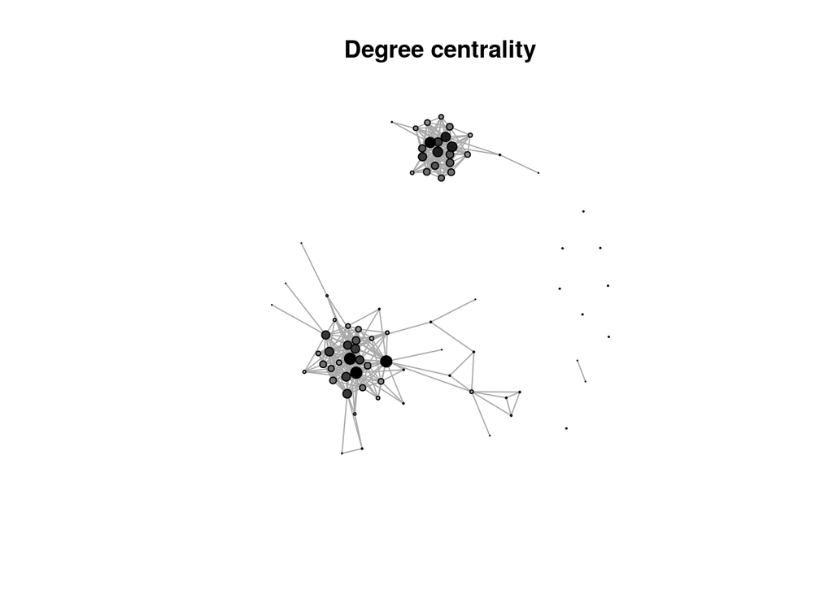

```r
layout_ <- layout.fruchterman.reingold(graph)
our_colors <- colorRampPalette(list('white','black'))

deg_color <- our_colors(10)[as.numeric(cut(deg_c,breaks=10))]
plot(graph,layout=layout_, vertex.color=deg_color,
     vertex.size=deg_c*0.3, vertex.label=NA, main="Degree centrality")
```

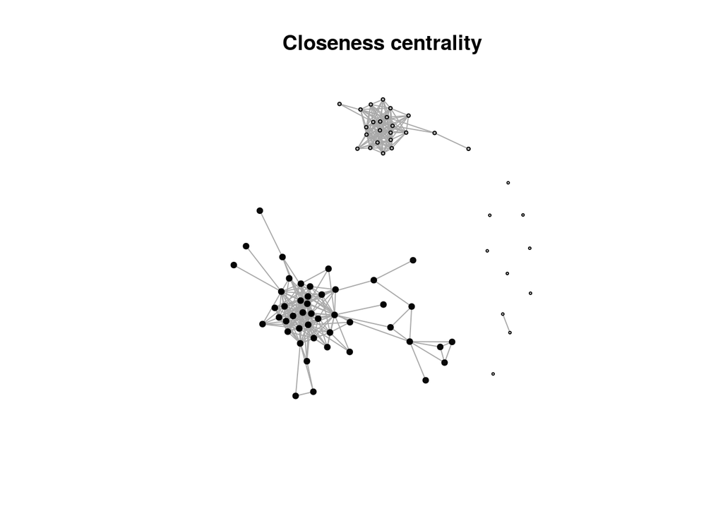

```r
deg_color <- our_colors(100)[as.numeric(cut(clos_c,breaks=100))]
plot(graph, layout=layout_, vertex.color=deg_color,
     vertex.size=clos_c*10000, vertex.label=NA, main="Closeness centrality")
```

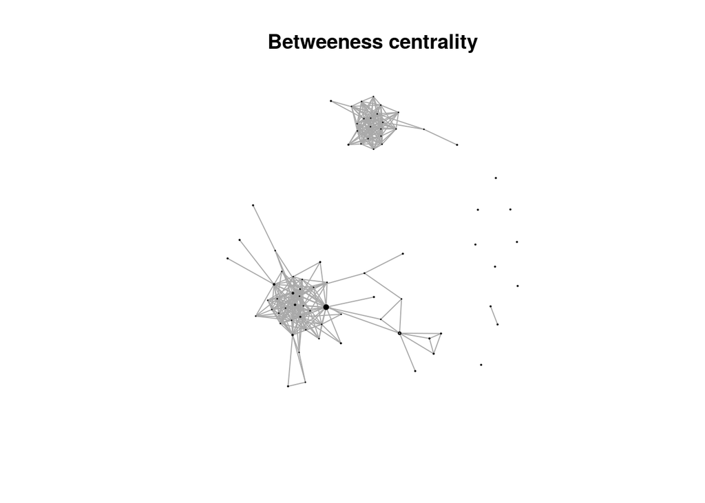

```r
deg_color <- our_colors(10)[as.numeric(cut(betw_c,breaks=10))]
plot(graph, layout=layout_, vertex.color=deg_color,
     vertex.size=betw_c/100, vertex.label=NA, main="Betweeness centrality")
```

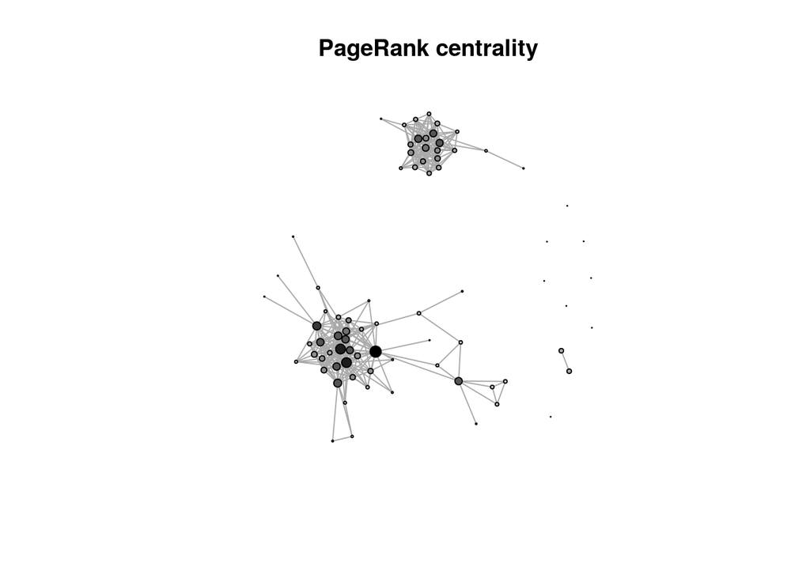

```r
deg_color <- our_colors(10)[as.numeric(cut(p_r,breaks=10))]
plot(graph, layout=layout_, vertex.color=deg_color,
     vertex.size=p_r*200, vertex.label=NA, main="PageRank centrality")
```

Hence, 1. In my vk network there are many nodes with close to zero betweennes centrality. 2. The PageRank and Degree values are quite similar. (I’t predictable, because random walk in PageRank directly depends on the degree of vertex.)

### Assortative Mixing according to node attributes

```r
assortativity_degree(graph, directed = F)
```

```
## [1] -0.02054211
```

```r
assortativity(graph, types1=clos_c, types2=NULL, directed=F)
```

```
## [1] 0.9996798
```

```r
assortativity(graph, types1=betw_c, types2=NULL, directed=F)
```

```
## [1] 0.04062778
```

```r
assortativity(graph, types1=p_r, types2=NULL, directed=F)
```

```
## [1] -0.09625419
```

### Node structural equivalence/similarity

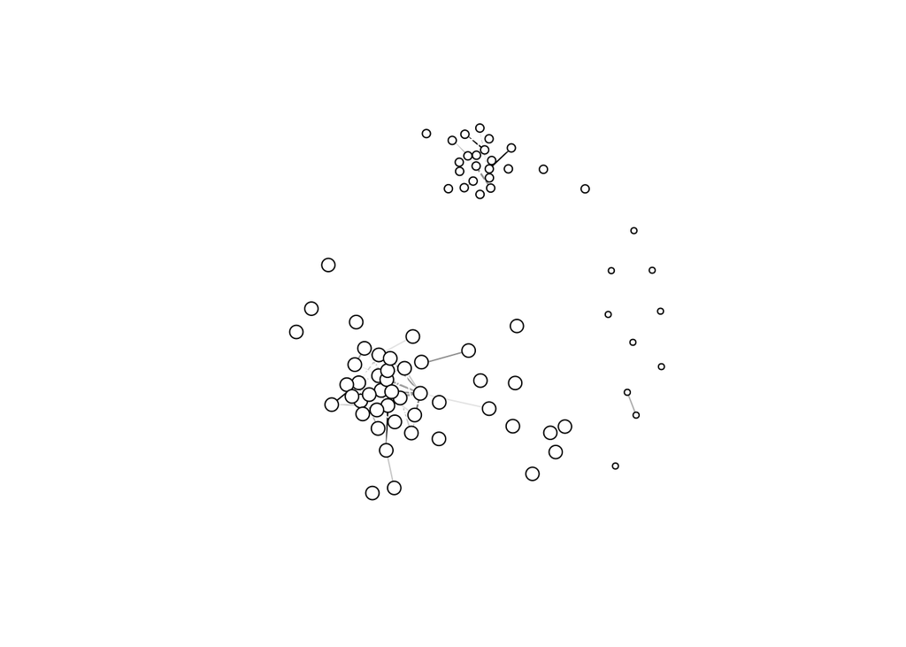

```r
sim.matrix <- similarity(graph, method = "dice")
degCol <- our_colors(10)[as.numeric(cut(sim.matrix,breaks=10))]
plot(graph, layout=layout_, edge.color=degCol, vertex.color=clos_c,
     vertex.size=clos_c*20000, vertex.label=NA)
```

### The closest random graph model similar to your SN

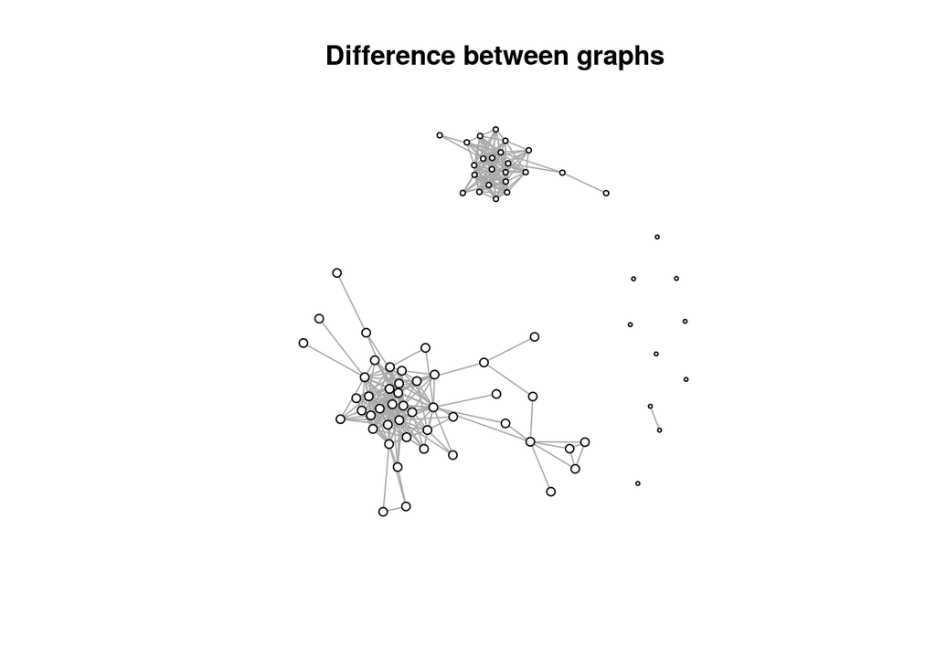

```r
gr <- erdos.renyi.game(vcount(graph), p.or.m = ecount(graph), type="gnm")
d <- graph.difference(graph, gr)
plot(d, layout=layout_,vertex.color=clos_c, vertex.size=clos_c*12000, vertex.label=NA,main="Difference between graphs")
```

## 3 Community Detection ### Search for cliques, hierarchical k-cores

Cliques

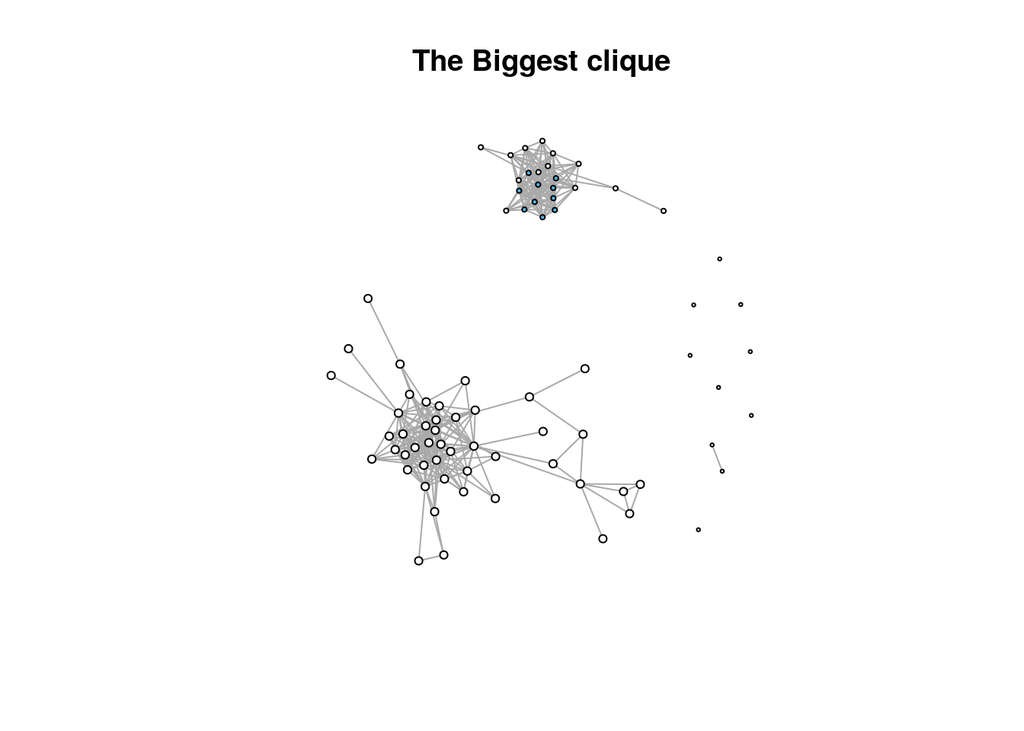

```r
largest = largest.cliques(graph)

labels = rep(0, vcount(graph))
labels[largest[[1]]] = 2
plot(graph,layout=layout_,vertex.color = labels,
     vertex.size=clos_c*10000,vertex.label=NA,main="The Biggest clique")
```

K-core

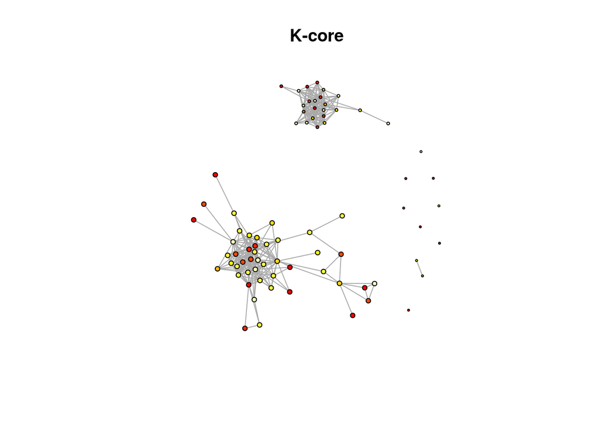

```r
coreness <- graph.coreness(graph)
max_cor <- max(coreness)
color_bar <- heat.colors(max_cor)
plot(graph,layout=layout_, vertex.color = color_bar[coreness], vertex.size=clos_c*10000, vertex.label=NA, main="K-core")
```

### Best results of various community detection algorithms, at least, hierarchical spectral clustering and modularity optimization should be applied with another TWO algorithms and compared in terms of stability of clustering. You may use communities, graph-tool, etc

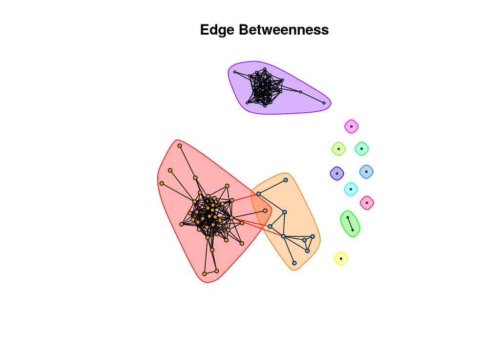

```r
edge_bet <- edge.betweenness.community(graph)
plot(edge_bet, layout=layout_, graph, vertex.color=edge_bet, vertex.size=clos_c*10000, vertex.label=NA, main="Edge Betweenness")
```

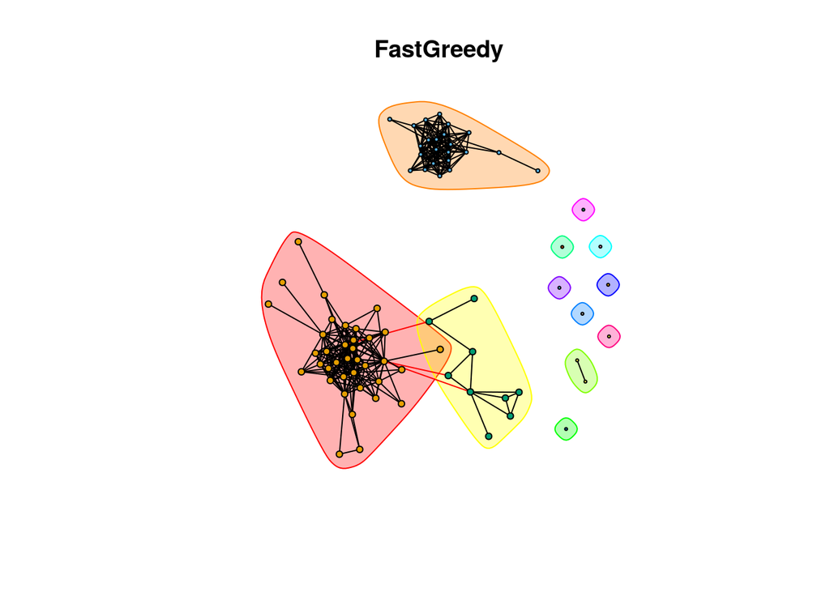

```r
fast_gr <- fastgreedy.community(graph)
plot(fast_gr, layout=layout_, graph, vertex.color = fast_gr, vertex.size=clos_c*10000, vertex.label=NA,main="FastGreedy")
```

## 4 Extracting friendship graph

First of all, I extracted frendsip graph using VK API (more precisely - vkR library)

Firstly, I created application in vk as described in example(https://cs.hse.ru/data/2017/04/04/1168473284/vkR_eng.pdf), after that I authorized and got access_token

```r
app_id <- 6069176
#vkOAuth(app_id) I commented this string in HTML report.
```

Get friends list:

```r
access_token <- "d1ce1087a992fffac5eab3413b2a92f0ac11364922f0732c077646d196ea353c09dbe99d50d0363e51277"
my_vk_id <- 250570961
setAccessToken(access_token)
friends <- getFriends(user_id=my_vk_id)
friends_count <- length(friends$items)
friends_str <- toString(friends$items)
```

Get mutual friends.

```r
mutual_friends <- getMutual(target_uid=0, target_uids=friends_str, offset=0, count=friends_count)
```

Parse data and save in csv format (Need for further imaging)

```r
fr_list <- list()

for (i in 1:friends_count) {
  if (mutual_friends[["common_count"]][i] != 0) {
    for (j in 1:(mutual_friends[["common_count"]][i])) {
      text <- mutual_friends[["id"]][i]
      text <- paste(text, mutual_friends[[2]][[i]][j], sep=",")
      fr_list[length(fr_list)+1] <- text
    }
  } else {
    fr_list[length(fr_list)+1] <- mutual_friends[["id"]][i]
  }
}
text1 <- paste0(fr_list, collapse=NULL)
write(text1, "/home/skv/sna_skvortsov/edgelist_.csv")
```

We now turn to the task 1